# R Notebook

```r
library(tidyverse)
library(here)
```

```r
golang <- read.csv("golang.csv")
java <- read.csv("java.csv")
java.go <- rbind(golang, java)
```

Para o experimento da questão 4, guardamos o valor do consumo de memória de um mesmo programa em duas linguagens distintas, sendo elas Java(utilizando threads) e Golang(utilizando goroutine), em dois csvs.

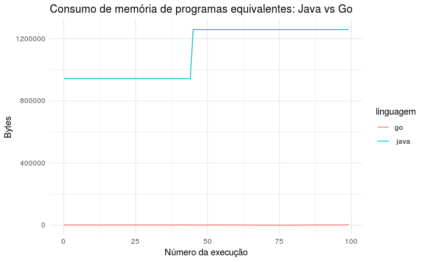

Como podemos ver, a diferença dos valores do consumo estão bem altas, então seria melhor estabilizarmos as escalas e melhorar a visualização dos dados. Para isso, podemos utilizar o log10 nos bytes e obtemos o resultado abaixo:

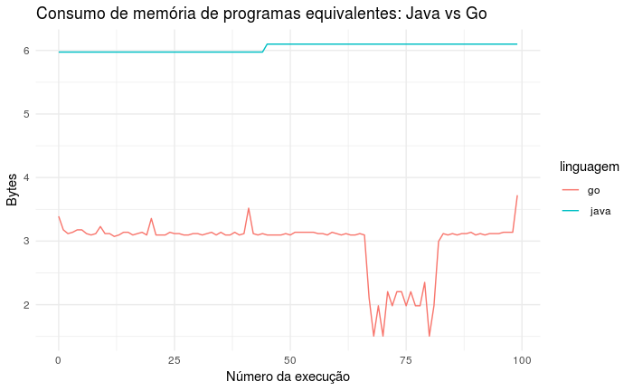

Como podemos observar com os gráficos acima, a utilização de threads em Java possui um consumo de memória bem mais elevado que se utilizarmos goroutines em Go. Podemos ver mais claramente esses resultados com a sumarização dos dados a seguir:

```r
java.go %>%
  group_by(linguagem) %>%
  summarise(média = mean(bytes),
            mediana = median(bytes),
            max.bytes = max(bytes),
            min.bytes = min(bytes))
```

| linguagem | média | mediana | max.bytes | min.bytes |
| --- | --- | --- | --- | --- |
| go | 1210.48 | 1312 | 5280 | 32 |
| java | 1116979.20 | 1258704 | 1258704 | 943760 |

Assim como dito anteriormente, podemos ver em números que os resultados de consumo são muito mais elevados para Java, como podemos observar acima, por exemplo, o consumo mínimo com thread é de 943760 bytes e com goroutines é de 32 bytes, uma diferença enorme de consumo. Dessa maneira, podemos concluir que a estratégia de goroutines consume menos mémoria do que utilizar threads.